# Capstone Milestone Report

Alejandro Andrade

11/16/2017

## Summary

This is a first report on my capstone project. The overarching goal is to develop a text-predictive application in Shiny. To create the predictive algorithm, a corpus is analyzed to acquire the empirical distribution of word frequencies.

## Preprocessing of Corpus

There were three goals at this step: 1) Read all English data and compute descriptive statistics; 2) Capture a random sample of the corpus and convert words into clean tokens; and 3) perform an exploratory analysis of the empirical coocurrence of words.

## Descriptive Statistics

Table 1. Corpus descriptive statistics

|  | nLines | totWords | meanWordLine | maxWordLine | totCharacters | meanCharLine | maxCharLine |
| --- | --- | --- | --- | --- | --- | --- | --- |
| en_US.blogs.txt | 899288 | 37546246 | 42 | 6726 | 206824505 | 230 | 40833 |
| en_US.news.txt | 1010242 | 34762395 | 34 | 1796 | 203223159 | 201 | 11384 |
| en_US.twitter.txt | 2360148 | 30093369 | 13 | 47 | 162096031 | 69 | 140 |

## Sampling and Cleaning

```r
data.folder = "/Users/alejandro/Coursera Data Science Capstone Data/en_US/"
myFiles = list.files(data.folder, pattern = ".txt")
linesToRead = 2
con = file(paste0(data.folder, myFiles[1]), "r")
myLines = readLines(con, linesToRead)
close.connection(con)
sentences = myLines %>%
        tokenize_sentences() %>%
        unlist()
tokens = sentences[1] %>%
        cleanSentence
```

```
## [1] "Original sentence:"
## [1] "In the years thereafter, most of the Oil fields and platforms were named after pagan “gods”."
## [1] "tokenizing..."
## [1] "removing numbers and non-ASCII characters..."
## [1] "Expanding contractions..."
## [1] "Cleaning bad words..."
## [1] "Spell checking..."
```

```
##  [1] "in"         "the"        "years"      "thereafter" "most"
##  [6] "of"         "the"        "oil"        "fields"     "and"
## [11] "platforms"  "were"       "named"      "after"      "pagan"
## [16] "gods"
```

## Exploratory Analysis

### Frequencies

Table 2 shows the most frequent terms, bigrams, and trigrams in the sample

Table 2. Frequency of terms in sample

| wordFreqTotal.Rdata | Freq | biGramsTotal.Rdata | Freq | triGramsTotal.Rdata | Freq |
| --- | --- | --- | --- | --- | --- |
| the | 47411 | of the | 4237 | i do not | 476 |
| to | 27453 | in the | 4004 | one of the | 343 |
| and | 23914 | it is | 2654 | it is a | 297 |
| a | 23751 | i am | 2572 | a lot of | 280 |
| of | 20046 | to the | 2109 | i am not | 241 |
| i | 19583 | for the | 2019 | thanks for the | 240 |

### Coverage

Figure 1 shows the coverage the number of terms, bigrams, and trigrams achieve in the sample

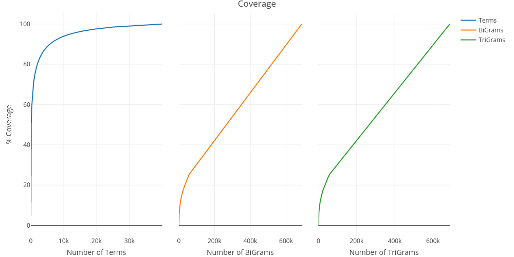

### Languages

Figure 2 shows the distribution of other languages besides English encountered in the sample.

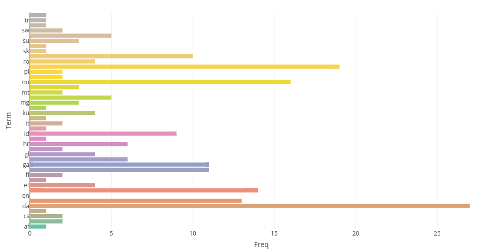

Table 3 shows the ten most prevalent languages in the sample.

Table 3. Frequency of languages

| Term | Freq | Perc | CumPerc |
| --- | --- | --- | --- |
| en | 72118 | 99.71 | 99.71 |
| da | 27 | 0.04 | 99.75 |
| pt | 19 | 0.03 | 99.78 |
| no | 16 | 0.02 | 99.80 |
| es | 14 | 0.02 | 99.82 |
| de | 13 | 0.02 | 99.84 |
| fr | 11 | 0.02 | 99.85 |
| ga | 11 | 0.02 | 99.87 |
| rw | 10 | 0.01 | 99.88 |
| id | 9 | 0.01 | 99.89 |

### Empirical frequencies

Figure 3 shows the empirical coocurrence of bigrams in the sample.

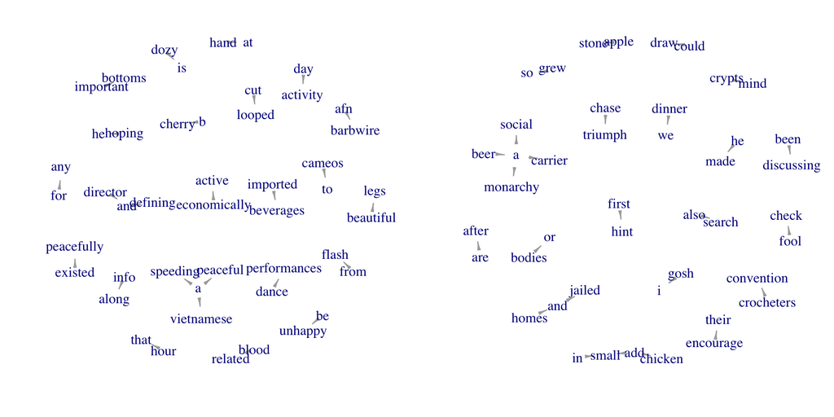

Figure 3. Word networks from sampled bigrams.

## Predictive Algorithm: First stab

A first attempt at creating a prediction algorithm is shown in the function *wordPredict*. This algorithm takes a sentence as an input, extracts the last word, cleans it, and then uses the empirical bigrams as a Markov transition probability to predict the most likely next word the user is about to type. The *wordPredict* function returns a list of the most probable word (according to the bigrams data base) and the three most probable alternatives. In case the last word in sentence is not in the data base, the algorithm randomly samples the data base to offer some possible alternatives.

```r
biGrams = read.csv(paste0(data.folder, "wordPrediction-bigrams.csv"))
source("wordPrediction/wordPredict.R")

sentence = "I am on a"
wordPredict(sentence, biGrams)
```

```
## $myWordPrediction
## [1] "lot"
##
## $wordAlternatives
## [1] "few"    "great"  "little"
```

```r
sentence = "My father wasn't in the house"
wordPredict(sentence, biGrams)
```

```
## $myWordPrediction
## [1] "and"
##
## $wordAlternatives
## [1] "is" "of" "in"
```

```r
sentence = "I like my biplane"
wordPredict(sentence, biGrams)
```

```
## $myWordPrediction
## NULL
##
## $wordAlternatives
## [1] "outside" "share"   "swim"
```